# Herrschaft_Ryan_Assignment4_R_Markdown

Ryan Herrschaft, 11/21/19 This is the R-script for assignment 4

First I start out with some code to set up the document.

```r
#Clean out environment
rm(list = ls())


#Session info
date()
```

```
[1] "Thu Nov 21 10:35:25 2019"
```

```r
#install needed packages
#install.packages("dslabs")
#install.packages ("tidyverse")
#install.packages("Hmisc")
library(Hmisc)
library (dslabs)
library (tidyverse)
bednet <- read_csv("C:/Users/rherrsch/Downloads/ghana_bednet.csv")
```

```
2 parsing failures.
 row    col               expected actual                                           file
2393 follyr no trailing characters A      'C:/Users/rherrsch/Downloads/ghana_bednet.csv'
5743 follyr a double               twelve 'C:/Users/rherrsch/Downloads/ghana_bednet.csv'
```

```r
bednet
```

| cluster | bednet | agemn | outcome | follyr | agegp | sex | idno |
| --- | --- | --- | --- | --- | --- | --- | --- |
| 1 | 1 | 6.012321 | 0 | 0.624657500 | 0 | 0 | 1 |
| 1 | 1 | 29.963040 | 0 | 1.293150700 | 2 | 1 | 2 |
| 1 | 1 | 6.012321 | 0 | 2.000000000 | 0 | 1 | 3 |
| 1 | 1 | 41.429157 | 0 | 1.545205500 | 3 | 0 | 4 |
| 1 | 1 | 6.012321 | 0 | 1.967123200 | 0 | 1 | 5 |
| 1 | 1 | 36.501026 | 0 | 1.956164400 | 3 | 1 | 6 |
| 1 | 1 | 57.067760 | 0 | 0.241095890 | 4 | 0 | 7 |
| 1 | 1 | 34.989735 | 0 | 1.539725900 | 2 | 1 | 8 |
| 1 | 1 | 45.568787 | 0 | 1.199999900 | 3 | 0 | 9 |
| 1 | 1 | 46.488705 | 0 | 1.123287700 | 3 | 0 | 10 |

[output cut: 990 more lines]

Questions 1 & 2: There are eight variables and 26,342 observations

```r
describe(bednet)
```

```
bednet

 8  Variables      26342  Observations
----------------------------------------------------------------
cluster
       n  missing distinct     Info     Mean      Gmd      .05
   26342        0       96        1    51.41    31.54        6
     .10      .25      .50      .75      .90      .95
      11       29       52       75       88       93

lowest :  1  2  3  4  5, highest: 92 93 94 95 96
----------------------------------------------------------------
bednet
       n  missing distinct     Info      Sum     Mean      Gmd
   26342        0        2     0.75    13313   0.5054      0.5

----------------------------------------------------------------
agemn
       n  missing distinct     Info     Mean      Gmd      .05
   26342        0     1641    0.976    25.29    20.27    6.012
     .10      .25      .50      .75      .90      .95
   6.012    6.012   22.505   41.298   52.399   56.476

lowest :  6.012321  6.045175  6.078029  6.110883  6.143737
highest: 59.761806 59.794662 59.827515 59.860370 59.893223
----------------------------------------------------------------
outcome
       n  missing distinct     Info      Sum     Mean      Gmd
   26342        0        2    0.094      857  0.03253  0.06295

----------------------------------------------------------------
follyr
       n  missing distinct     Info     Mean      Gmd      .05
   26340        2      730     0.97    1.266   0.7675   0.1342
     .10      .25      .50      .75      .90      .95
  0.2630   0.6438   1.3534   2.0000   2.0000   2.0000

lowest : 0.002739726 0.005479452 0.008219178 0.010958904 0.013698630
highest: 1.989041000 1.991780800 1.994520500 1.997260200 2.000000000
----------------------------------------------------------------
```

[output cut: 11 more lines]

```
       n  missing distinct
   26342        0        4

Value          .     0     1     F
Frequency      1 13305 13031     5
Proportion 0.000 0.505 0.495 0.000
----------------------------------------------------------------
idno
       n  missing distinct     Info     Mean      Gmd      .05
   26342        0    26342        1    13172     8781     1318
     .10      .25      .50      .75      .90      .95
    2635     6586    13172    19757    23708    25025

lowest :     1     2     3     4     5, highest: 26338 26339 26340 26341 26342
----------------------------------------------------------------
```

```r
#Questions 1 & 2: There are eight variables and 26,342 observations

summary(bednet)
```

```
    cluster          bednet           agemn
 Min.   : 1.00   Min.   :0.0000   Min.   : 6.012
 1st Qu.:29.00   1st Qu.:0.0000   1st Qu.: 6.012
 Median :52.00   Median :1.0000   Median :22.505
 Mean   :51.41   Mean   :0.5054   Mean   :25.287
 3rd Qu.:75.00   3rd Qu.:1.0000   3rd Qu.:41.298
 Max.   :96.00   Max.   :1.0000   Max.   :59.893

    outcome            follyr            agegp
 Min.   :0.00000   Min.   :0.00274   Min.   :0.000
 1st Qu.:0.00000   1st Qu.:0.64384   1st Qu.:0.000
 Median :0.00000   Median :1.35342   Median :1.000
 Mean   :0.03253   Mean   :1.26552   Mean   :1.594
 3rd Qu.:0.00000   3rd Qu.:2.00000   3rd Qu.:3.000
 Max.   :1.00000   Max.   :2.00000   Max.   :4.000
                   NA's   :2
     sex                 idno
 Length:26342       Min.   :    1
 Class :character   1st Qu.: 6586
 Mode  :character   Median :13172
                    Mean   :13172
                    3rd Qu.:19757
                    Max.   :26342
```

3.)What proportion of the children represented in the dataset are male?

```r
#Note, 0 is male, 1 is female
#Need to clean sex variable

bednet$sex[bednet$sex=="F"] <- 1

bednet$sex[bednet$sex=="."] <- NA

describe(bednet$sex)
```

```
bednet$sex
       n  missing distinct
   26341        1        2

Value          0     1
Frequency  13305 13036
Proportion 0.505 0.495
```

4.) What is the total number of years of follow-up experienced by female children in intervention areas?

```r
#Note that the variable "bednet" says if the child was in an intervention area. 0=control, 1=intervention
#Also note that for sex variable 1=female
#and, follyr is the continuous follow-up variable

female_only <- filter(bednet, sex == 1, bednet == 1)
describe (female_only$follyr)
```

```
female_only$follyr
       n  missing distinct     Info     Mean      Gmd      .05
    6609        1      718    0.969     1.27   0.7662   0.1288
     .10      .25      .50      .75      .90      .95
  0.2658   0.6603   1.3671   2.0000   2.0000   2.0000

lowest : 0.002739726 0.005479452 0.008219178 0.010958904 0.013698630
highest: 1.989041000 1.991780800 1.994520500 1.997260200 2.000000000
```

```r
#There was a missing value that had to be accounted for.

sum(female_only$follyr, na.rm = TRUE)
```

```
[1] 8395.184
```

The total number of years is 8395.184

5.)What is the proportion of all children in cluster 52 who died during followup?

```r
# Note that outcome is the variable that tells you if a child died 0=no, 1=yes

cluster_52_only <- filter(bednet, cluster == "52")
describe (cluster_52_only$outcome)
```

```
cluster_52_only$outcome
       n  missing distinct     Info      Sum     Mean      Gmd
     370        0        2    0.071        9  0.02432  0.04759
```

9 out of the 370 children died. This is 2.43% of children in cluster 52.

6.) What is the mean and standard deviation of the subjects age?

```r
mean(bednet$agemn)
```

```
[1] 25.28693
```

```r
sd(bednet$agemn)
```

```
[1] 18.02471
```

The mean age is 25.29. The standard deviation of age is 18.025.

7. Calculate the mortality rate (number or deaths per person year of follow up) in the control arm and, separately, in the intervention arm.

```r
#bednet is control/intervention varaible. 0 means control, 1 means intervention

control_only <- filter(bednet, bednet ==0)
intervention_only <- filter(bednet, bednet==1)


#mortality rate per person per year can be calculated by (number of deaths) over follyr(person years number of followup)
#because deaths are coded as 1, we can count deaths by taking the sum of the outcome variable

sum_deaths_control <-sum(control_only$outcome)
sum_deaths_control
```

```
[1] 461
```

```r
#there were 461 deaths in the control group.

#from here, we find the number of deaths in the control sample. We take this number and divide it by the sum of follyr.

sum_follow_year_control <- sum(control_only$follyr, na.rm = TRUE)
sum_follow_year_control
```

```
[1] 16492.83
```

```r
#Finally, we take the number of deaths and divide by sum of follyr
mort_rate_control <-(sum_deaths_control)/(sum_follow_year_control)
mort_rate_control
```

```
[1] 0.02795154
```

```r
#The mortality person rate per person per year for the control group is .02795


#We now repeat these steps but for the intervention group.
sum_deaths_intervention <-sum(intervention_only$outcome)
sum_deaths_intervention
```

```
[1] 396
```

```r
#there were 396 deaths in the intervention group.

#from here, we find the number of deaths in the intervention sample. We take this number and divide it by the sum of follyr.
sum_follow_year_intervention <- sum(intervention_only$follyr, na.rm = TRUE)
sum_follow_year_intervention
```

```
[1] 16841.04
```

```r
#Finally, we take the number of deaths and divide by sum of follyr
mort_rate_intervention <-(sum_deaths_intervention)/(sum_follow_year_intervention)
mort_rate_intervention
```

```
[1] 0.02351399
```

```r
# The morality rate per person per year for the intervention group is  0.02351
```

The mortality person rate per person per year for the control group is .02795

The morality rate per person per year for the intervention group is 0.02351

8. Make a bar chart showing the proportion of participants who died in each cluster.

```r
#I had trouble using the "group by" command to generate these results. Instead, I used aggregate

mean_death_by_cluster <- aggregate(bednet$outcome, by=list(bednet$cluster), FUN=mean) %>% rename(cluster_group = Group.1) %>% rename(Prop_death = x)

mean_death_by_cluster
```

| cluster_group | Prop_death |
| --- | --- |
| 1 | 0.065217391 |
| 2 | 0.050691244 |
| 3 | 0.032432432 |
| 4 | 0.056603774 |
| 5 | 0.032142857 |
| 6 | 0.030000000 |
| 7 | 0.028688525 |
| 8 | 0.035087719 |
| 9 | 0.027586207 |
| 10 | 0.040178571 |

[output cut: 86 more lines]

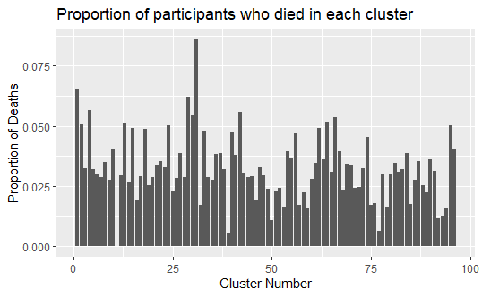

```r
barplot1<-ggplot(data= mean_death_by_cluster, aes(x= cluster_group, y= Prop_death)) + geom_bar(stat="identity") +ggtitle("Proportion of participants who died in each cluster") +labs(y= "Proportion of Deaths", x="Cluster Number")
barplot1
```

9. Use the glm() function from base R’s stats package, and the formula ‘out- come ~ bednet’with the family argument specified as ’binomial(link = “logit”)’ to fit a logistic regression. Print the summary of this regression in your document.

```r
model <- glm(outcome ~ bednet, data=bednet, binomial(link= "logit"))
summary (model)
```

```
Call:
glm(formula = outcome ~ bednet, family = binomial(link = "logit"),
    data = bednet)

Deviance Residuals:
    Min       1Q   Median       3Q      Max
-0.2684  -0.2684  -0.2457  -0.2457   2.6515

Coefficients:
            Estimate Std. Error z value Pr(>|z|)
(Intercept) -3.30551    0.04742 -69.705   <2e-16 ***
bednet      -0.17937    0.06965  -2.575     0.01 *
---
Signif. codes:  0 ‘***’ 0.001 ‘**’ 0.01 ‘*’ 0.05 ‘.’ 0.1 ‘ ’ 1

(Dispersion parameter for binomial family taken to be 1)

    Null deviance: 7557.1  on 26341  degrees of freedom
Residual deviance: 7550.4  on 26340  degrees of freedom
AIC: 7554.4

Number of Fisher Scoring iterations: 6
```

```r
print(model)
```

```
Call:  glm(formula = outcome ~ bednet, family = binomial(link = "logit"),
    data = bednet)

Coefficients:
(Intercept)       bednet
    -3.3055      -0.1794

Degrees of Freedom: 26341 Total (i.e. Null);  26340 Residual
Null Deviance:      7557
Residual Deviance: 7550     AIC: 7554
```

10. Was being in an intervention cluster (i.e. having bednets) associated with lower or higher probability of a child dying during the course of the trial? What was the coefficient (or odds ratio (specify which)) and p-value for this conclusion.

```r
exp(coef(model))
```

```
(Intercept)      bednet
 0.03668046  0.83579308
```

The odds ratio is 0.836 (p<.05), meaning that those with bednets had a decreased chance of having a child die during the course of the trial.